# Ford Go Bike Data Exploration

## Introduction

> This data set includes information about individual rides made in a bike-sharing system covering the greater San Francisco Bay area

## Preliminary Wrangling

```python
# import all packages and set plots to be embedded inline
import numpy as np
import pandas as pd
import matplotlib.pyplot as plt
import seaborn as sb
import datetime as dt
%matplotlib inline
```

```python
#Loading the dataset
df = pd.read_csv("C:/Users/eyego/Downloads/201902-fordgobike-tripdata.csv")
df.head()
```

|  | duration_sec | start_time | end_time | start_station_id | start_station_name | start_station_latitude | start_station_longitude | end_station_id | end_station_name | end_station_latitude | end_station_longitude | bike_id | user_type | member_birth_year | member_gender | bike_share_for_all_trip |
| --- | --- | --- | --- | --- | --- | --- | --- | --- | --- | --- | --- | --- | --- | --- | --- | --- |
| 0 | 52185 | 2019-02-28 17:32:10.1450 | 2019-03-01 08:01:55.9750 | 21.0 | Montgomery St BART Station (Market St at 2nd St) | 37.789625 | -122.400811 | 13.0 | Commercial St at Montgomery St | 37.794231 | -122.402923 | 4902 | Customer | 1984.0 | Male | No |
| 1 | 42521 | 2019-02-28 18:53:21.7890 | 2019-03-01 06:42:03.0560 | 23.0 | The Embarcadero at Steuart St | 37.791464 | -122.391034 | 81.0 | Berry St at 4th St | 37.775880 | -122.393170 | 2535 | Customer | NaN | NaN | No |
| 2 | 61854 | 2019-02-28 12:13:13.2180 | 2019-03-01 05:24:08.1460 | 86.0 | Market St at Dolores St | 37.769305 | -122.426826 | 3.0 | Powell St BART Station (Market St at 4th St) | 37.786375 | -122.404904 | 5905 | Customer | 1972.0 | Male | No |
| 3 | 36490 | 2019-02-28 17:54:26.0100 | 2019-03-01 04:02:36.8420 | 375.0 | Grove St at Masonic Ave | 37.774836 | -122.446546 | 70.0 | Central Ave at Fell St | 37.773311 | -122.444293 | 6638 | Subscriber | 1989.0 | Other | No |
| 4 | 1585 | 2019-02-28 23:54:18.5490 | 2019-03-01 00:20:44.0740 | 7.0 | Frank H Ogawa Plaza | 37.804562 | -122.271738 | 222.0 | 10th Ave at E 15th St | 37.792714 | -122.248780 | 4898 | Subscriber | 1974.0 | Male | Yes |

```python
# rows and columns
df.shape
```

```
(183412, 16)
```

```python
#information about rows and columns
df.info()
```

```
<class 'pandas.core.frame.DataFrame'>
RangeIndex: 183412 entries, 0 to 183411
Data columns (total 16 columns):
 #   Column                   Non-Null Count   Dtype
---  ------                   --------------   -----
 0   duration_sec             183412 non-null  int64
 1   start_time               183412 non-null  object
 2   end_time                 183412 non-null  object
 3   start_station_id         183215 non-null  float64
 4   start_station_name       183215 non-null  object
 5   start_station_latitude   183412 non-null  float64
 6   start_station_longitude  183412 non-null  float64
 7   end_station_id           183215 non-null  float64
 8   end_station_name         183215 non-null  object
 9   end_station_latitude     183412 non-null  float64
 10  end_station_longitude    183412 non-null  float64
 11  bike_id                  183412 non-null  int64
 12  user_type                183412 non-null  object
 13  member_birth_year        175147 non-null  float64
 14  member_gender            175147 non-null  object
 15  bike_share_for_all_trip  183412 non-null  object
dtypes: float64(7), int64(2), object(7)
memory usage: 22.4+ MB
```

```python
# Check for null values
df.isnull().sum()
```

```
duration_sec                  0
start_time                    0
end_time                      0
start_station_id            197
start_station_name          197
start_station_latitude        0
start_station_longitude       0
end_station_id              197
end_station_name            197
end_station_latitude          0
end_station_longitude         0
bike_id                       0
user_type                     0
member_birth_year          8265
member_gender              8265
bike_share_for_all_trip       0
dtype: int64
```

### What is the structure of your dataset?

> The dataset contains the details of 183412 rows with 16 attributes, most variables are numeric in nature.

### What is/are the main feature(s) of interest in your dataset?

> The main features of interest are: gender, user type, duration_sec, start_hour, age and stations

### What features in the dataset do you think will help support your investigation into your feature(s) of interest?

> I thinks the feature that will support my investigation are duration_sec and user_type

## Data Cleaning

Data cleaning follows three programatic steps;

- Define
- Code
- Test

```python
#Lets make a copy of the dataframe
CleanFord_bike = df.copy()
```

```python
# 1) Define:
# change the data type for start and end time to be datetime64[ns]
# change the data type for bike_share_for_all_trip to be bool

#code:
CleanFord_bike.start_time = pd.to_datetime(df.start_time)
CleanFord_bike.end_time = pd.to_datetime(df.end_time)
CleanFord_bike.bike_share_for_all_trip = (df.bike_share_for_all_trip == 'Yes')
```

```python
#Code:
# change the data type for bike_share_for_all_trip to be bool
CleanFord_bike.bike_share_for_all_trip = (df.bike_share_for_all_trip == 'Yes')
```

```python
# 2) Define:
# Drop the null values

#code
CleanFord_bike.dropna(axis=0,inplace=True)
```

```python
#Test
CleanFord_bike.info()
```

```
<class 'pandas.core.frame.DataFrame'>
Int64Index: 174952 entries, 0 to 183411
Data columns (total 16 columns):
 #   Column                   Non-Null Count   Dtype
---  ------                   --------------   -----
 0   duration_sec             174952 non-null  int64
 1   start_time               174952 non-null  datetime64[ns]
 2   end_time                 174952 non-null  datetime64[ns]
 3   start_station_id         174952 non-null  float64
 4   start_station_name       174952 non-null  object
 5   start_station_latitude   174952 non-null  float64
 6   start_station_longitude  174952 non-null  float64
 7   end_station_id           174952 non-null  float64
 8   end_station_name         174952 non-null  object
 9   end_station_latitude     174952 non-null  float64
 10  end_station_longitude    174952 non-null  float64
 11  bike_id                  174952 non-null  int64
 12  user_type                174952 non-null  object
 13  member_birth_year        174952 non-null  float64
 14  member_gender            174952 non-null  object
 15  bike_share_for_all_trip  174952 non-null  bool
dtypes: bool(1), datetime64[ns](2), float64(7), int64(2), object(4)
memory usage: 21.5+ MB
```

```python
#Test
CleanFord_bike.isnull().sum()
```

```
duration_sec               0
start_time                 0
end_time                   0
start_station_id           0
start_station_name         0
start_station_latitude     0
start_station_longitude    0
end_station_id             0
end_station_name           0
end_station_latitude       0
end_station_longitude      0
bike_id                    0
user_type                  0
member_birth_year          0
member_gender              0
bike_share_for_all_trip    0
dtype: int64
```

- As we can see, the data types of the columns have changed based on its values and also all the null values have been dropped.

```python
# Description of the dataset
CleanFord_bike.describe()
```

|  | duration_sec | start_station_id | start_station_latitude | start_station_longitude | end_station_id | end_station_latitude | end_station_longitude | bike_id | member_birth_year |
| --- | --- | --- | --- | --- | --- | --- | --- | --- | --- |
| count | 174952.000000 | 174952.000000 | 174952.000000 | 174952.000000 | 174952.000000 | 174952.000000 | 174952.000000 | 174952.000000 | 174952.000000 |
| mean | 704.002744 | 139.002126 | 37.771220 | -122.351760 | 136.604486 | 37.771414 | -122.351335 | 4482.587555 | 1984.803135 |
| std | 1642.204905 | 111.648819 | 0.100391 | 0.117732 | 111.335635 | 0.100295 | 0.117294 | 1659.195937 | 10.118731 |
| min | 61.000000 | 3.000000 | 37.317298 | -122.453704 | 3.000000 | 37.317298 | -122.453704 | 11.000000 | 1878.000000 |
| 25% | 323.000000 | 47.000000 | 37.770407 | -122.411901 | 44.000000 | 37.770407 | -122.411647 | 3799.000000 | 1980.000000 |
| 50% | 510.000000 | 104.000000 | 37.780760 | -122.398279 | 101.000000 | 37.781010 | -122.397437 | 4960.000000 | 1987.000000 |
| 75% | 789.000000 | 239.000000 | 37.797320 | -122.283093 | 238.000000 | 37.797673 | -122.286533 | 5505.000000 | 1992.000000 |
| max | 84548.000000 | 398.000000 | 37.880222 | -121.874119 | 398.000000 | 37.880222 | -121.874119 | 6645.000000 | 2001.000000 |

- The min member_birth_year is 1878 this is an outlier, we can drop it

```python
# 3) Define
# Removing outliers that may hinder analysis

#Code:
Age=CleanFord_bike[CleanFord_bike.member_birth_year < 1940]
CleanFord_bike.drop(CleanFord_bike[(CleanFord_bike.member_birth_year < 1929 )].index, inplace = True)
Age
```

|  | duration_sec | start_time | end_time | start_station_id | start_station_name | start_station_latitude | start_station_longitude | end_station_id | end_station_name | end_station_latitude | end_station_longitude | bike_id | user_type | member_birth_year | member_gender | bike_share_for_all_trip |
| --- | --- | --- | --- | --- | --- | --- | --- | --- | --- | --- | --- | --- | --- | --- | --- | --- |
| 1285 | 148 | 2019-02-28 19:29:17.627 | 2019-02-28 19:31:45.967 | 158.0 | Shattuck Ave at Telegraph Ave | 37.833279 | -122.263490 | 173.0 | Shattuck Ave at 55th St | 37.840364 | -122.264488 | 5391 | Subscriber | 1900.0 | Male | True |
| 5197 | 217 | 2019-02-28 13:51:46.238 | 2019-02-28 13:55:24.127 | 70.0 | Central Ave at Fell St | 37.773311 | -122.444293 | 71.0 | Broderick St at Oak St | 37.773063 | -122.439078 | 5801 | Subscriber | 1931.0 | Male | False |
| 5266 | 384 | 2019-02-28 13:35:05.428 | 2019-02-28 13:41:30.223 | 84.0 | Duboce Park | 37.769200 | -122.433812 | 71.0 | Broderick St at Oak St | 37.773063 | -122.439078 | 6608 | Subscriber | 1931.0 | Male | False |
| 5447 | 147 | 2019-02-28 13:08:56.935 | 2019-02-28 13:11:24.062 | 84.0 | Duboce Park | 37.769200 | -122.433812 | 72.0 | Page St at Scott St | 37.772406 | -122.435650 | 5018 | Subscriber | 1931.0 | Male | False |
| 10827 | 1315 | 2019-02-27 19:21:34.436 | 2019-02-27 19:43:30.008 | 343.0 | Bryant St at 2nd St | 37.783172 | -122.393572 | 375.0 | Grove St at Masonic Ave | 37.774836 | -122.446546 | 6249 | Subscriber | 1900.0 | Male | False |
| ... | ... | ... | ... | ... | ... | ... | ... | ... | ... | ... | ... | ... | ... | ... | ... | ... |
| 177885 | 517 | 2019-02-01 18:38:40.471 | 2019-02-01 18:47:18.392 | 25.0 | Howard St at 2nd St | 37.787522 | -122.397405 | 30.0 | San Francisco Caltrain (Townsend St at 4th St) | 37.776598 | -122.395282 | 2175 | Subscriber | 1902.0 | Female | False |
| 177955 | 377 | 2019-02-01 18:23:33.411 | 2019-02-01 18:29:50.795 | 26.0 | 1st St at Folsom St | 37.787290 | -122.394380 | 321.0 | 5th St at Folsom | 37.780146 | -122.403071 | 5444 | Subscriber | 1933.0 | Female | True |
| 179280 | 355 | 2019-02-01 14:32:42.247 | 2019-02-01 14:38:37.896 | 134.0 | Valencia St at 24th St | 37.752428 | -122.420628 | 131.0 | 22nd St at Dolores St | 37.755000 | -122.425728 | 1815 | Subscriber | 1938.0 | Male | False |
| 182830 | 428 | 2019-02-01 07:45:05.934 | 2019-02-01 07:52:14.922 | 284.0 | Yerba Buena Center for the Arts (Howard St at ... | 37.784872 | -122.400876 | 67.0 | San Francisco Caltrain Station 2 (Townsend St... | 37.776639 | -122.395526 | 5031 | Subscriber | 1901.0 | Male | False |
| 183388 | 490 | 2019-02-01 00:39:53.112 | 2019-02-01 00:48:03.338 | 61.0 | Howard St at 8th St | 37.776513 | -122.411306 | 81.0 | Berry St at 4th St | 37.775880 | -122.393170 | 5411 | Subscriber | 1927.0 | Male | False |

203 rows × 16 columns

```python
# Test
CleanFord_bike.describe()
```

|  | duration_sec | start_station_id | start_station_latitude | start_station_longitude | end_station_id | end_station_latitude | end_station_longitude | bike_id | member_birth_year |
| --- | --- | --- | --- | --- | --- | --- | --- | --- | --- |
| count | 174875.000000 | 174875.000000 | 174875.000000 | 174875.000000 | 174875.000000 | 174875.000000 | 174875.000000 | 174875.000000 | 174875.000000 |
| mean | 704.028009 | 138.981141 | 37.771206 | -122.351758 | 136.604655 | 37.771401 | -122.351334 | 4482.518273 | 1984.839726 |
| std | 1642.537925 | 111.637185 | 0.100409 | 0.117748 | 111.333687 | 0.100314 | 0.117311 | 1659.218012 | 9.968641 |
| min | 61.000000 | 3.000000 | 37.317298 | -122.453704 | 3.000000 | 37.317298 | -122.453704 | 11.000000 | 1930.000000 |
| 25% | 323.000000 | 47.000000 | 37.770407 | -122.411901 | 44.000000 | 37.770407 | -122.411647 | 3799.000000 | 1980.000000 |
| 50% | 510.000000 | 104.000000 | 37.780760 | -122.398279 | 101.000000 | 37.781010 | -122.397437 | 4960.000000 | 1987.000000 |
| 75% | 789.000000 | 239.000000 | 37.797320 | -122.283093 | 238.000000 | 37.797673 | -122.286533 | 5505.000000 | 1992.000000 |
| max | 84548.000000 | 398.000000 | 37.880222 | -121.874119 | 398.000000 | 37.880222 | -121.874119 | 6645.000000 | 2001.000000 |

```python
# create column of day of the week
CleanFord_bike['day_of_week'] = pd.DatetimeIndex(CleanFord_bike['start_time']).strftime('%A')
# create column of the time of the day
CleanFord_bike['start_hour'] = CleanFord_bike['start_time'].apply(lambda time: time.hour)
CleanFord_bike['time_of_day'] = 'Morning'
CleanFord_bike['time_of_day'][(CleanFord_bike['start_hour'] >= 12) & (CleanFord_bike['start_hour'] <= 17)] = 'Afternoon'
CleanFord_bike['time_of_day'][(CleanFord_bike['start_hour'] >= 18) & (CleanFord_bike['start_hour'] <= 23)] = 'Night'

#Lets test
display(CleanFord_bike.head())
```

[output not shown]

5 rows × 21 columns

## Univariate Exploration

> In this section, investigate distributions of individual variables. If you see unusual points or outliers, take a deeper look to clean things up and prepare yourself to look at relationships between variables.

## 1. What kind of users are there? (user_type variate)

```
Subscriber    158315
Customer       16560
Name: user_type, dtype: int64
```

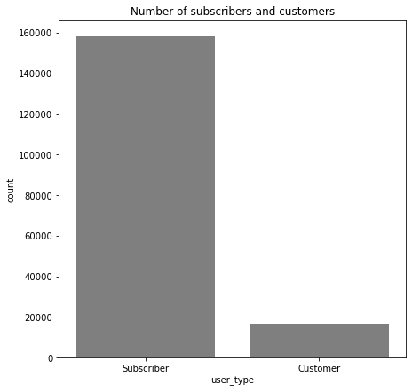

```python
# We will plot a bar plot
print(CleanFord_bike['user_type'].value_counts())
plt.figure(figsize = (7,7))
sb.countplot(data = CleanFord_bike, x = 'user_type', order = CleanFord_bike['user_type'].value_counts().index, color = sb.color_palette()[7]);
plt.title('Number of subscribers and customers');
```

> The bike users are mostly subscribers, more than three quarters

## 2. What gender are the most bike users? (Gender variate)

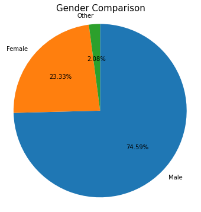

```python
plt.figure(figsize=(10,6))
sorted_counts = CleanFord_bike['member_gender'].value_counts()
plt.pie(sorted_counts, labels = sorted_counts.index, startangle = 90,
        counterclock = False, autopct='%1.2f%%');
plt.axis('square')
plt.title('Gender Comparison', fontsize=15);
```

- From the gender distribution males use bikes more than females

## 3. At what time of the day are trips mostly taken?

```
The percentage count of trips made in terms of times of the day(%)
Morning      38.53
Afternoon    38.31
Night        23.16
Name: time_of_day, dtype: float64
```

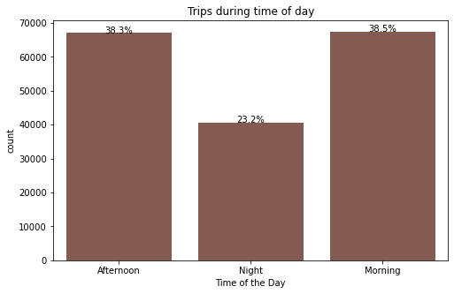

```python
#percentage of trips made in terms of times of the day
time_of_day_count = (CleanFord_bike['time_of_day'].value_counts()/CleanFord_bike['time_of_day'].count())*100
print("The percentage count of trips made in terms of times of the day(%)")
print(time_of_day_count.round(2).sort_values(ascending=False))

# plot distribution of day of week
plt.figure(figsize=[8, 5])
base_color = sb.color_palette()[5]
sb.countplot(data = CleanFord_bike, x = 'time_of_day', color = base_color)
n_points = CleanFord_bike.shape[0]
user_counts = CleanFord_bike['time_of_day'].value_counts()
locs, labels = plt.xticks()

# print frequency on the bar chart
for loc, label in zip(locs, labels):
    count = user_counts[label.get_text()]
    pct_string = '{:0.1f}%'.format(100*count/n_points)
    plt.text(loc, count-8, pct_string, ha='center')

plt.title('Trips during time of day')
plt.xlabel('Time of the Day')
plt.show()
```

## 4. What is the avarage trip duration generally?

```python
# lets see the mean of the duration_sec column
CleanFord_bike.duration_sec.describe()
```

```
count    174875.000000
mean        704.028009
std        1642.537925
min          61.000000
25%         323.000000
50%         510.000000
75%         789.000000
max       84548.000000
Name: duration_sec, dtype: float64
```

```python
# convert second to minutes
CleanFord_bike['duration_min'] = CleanFord_bike['duration_sec']/60
```

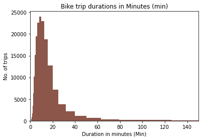

```python
# Visualize with histogram
bin_edges = 10**np.arange(0,3+0.1,0.1)
plt.hist(data=CleanFord_bike,x = 'duration_min',bins = bin_edges, color=base_color)
plt.xlabel('Duration in minutes (Min)')
plt.xlim(0,150)
plt.ylabel('No. of trips')
plt.title('Bike trip durations in Minutes (min)')
```

## 5. What is the daily usage of bikes?

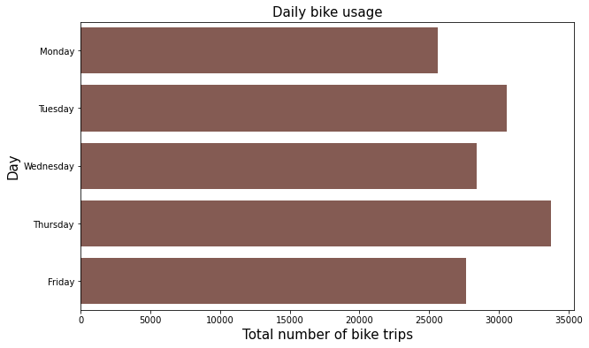

```python
plt.figure(figsize=[10,6])
order = ['Monday','Tuesday','Wednesday','Thursday','Friday']
sb.countplot(data = CleanFord_bike, y='day_of_week',color=base_color,order = order);
plt.xlabel('Total number of bike trips',fontsize = 15)
plt.ylabel('Day',fontsize = 15)
plt.title('Daily bike usage',fontsize = 15);
```

> FordGo bikes are mostly used on Thursdays as seen on the visualization above

## How many bike stations are there ?(station variate)

```python
CleanFord_bike.start_station_name.nunique()
```

```
329
```

## 6. Which are the most popular start and end stations

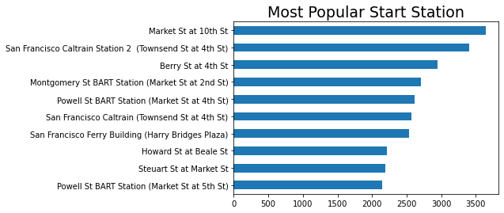

```python
# Start station:
plt.title('Most Popular Start Station', fontsize=19)
CleanFord_bike.start_station_name.value_counts(ascending=True).tail(10).plot.barh();
```

[figure not shown]

```python
#End station
plt.title('Most Popular End Stations', fontsize=15)
CleanFord_bike.value_counts(ascending=True).tail(10).plot.barh();
```

## Of the features you investigated, were there any unusual distributions? Did you perform any operations on the data to tidy, adjust, or change the form of the data? If so, why did you do this?

- Yes, there is some problem to this Ford GoBike data, such as:
- Quality issues for many columns, which is the dtype is not suitable with it's data
- Age has some outliers which may alter the distribution

### Of the features you investigated, were there any unusual distributions? Did you perform any operations on the data to tidy, adjust, or change the form of the data? If so, why did you do this?

- Subscribers are more than customers
- There are more males than females in the dataset
- Most used start station was Market st at 10th st

## 1. What is the relation between age and trip duration

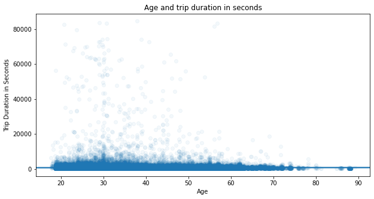

```python
#lets create a column of age
CleanFord_bike['Age'] = 2019 - CleanFord_bike.member_birth_year
Age
#let's plot
plt.figure(figsize=[10, 5])
sb.regplot(data = CleanFord_bike, x = 'Age', y = 'duration_sec', truncate=False, x_jitter=0.3, scatter_kws={'alpha':1/20});
plt.ylabel('Trip Duration in Seconds');
plt.title('Age and trip duration in seconds');
```

- People between 20-40 years take long trip durations

## 2. What is the duration distribution depending on user type?

[figure not shown]

```python
plt.figure(figsize = [10, 10]);
bins = np.arange(0, 10000, 50)

sb.countplot(data = CleanFord_bike, x = 'duration_sec', hue = 'user_type');

plt.title('Users and Trip Duration in Seconds');
```

- customers have a more varied duration than subscribers. The duration of use for subscribers is more narrowed to one point.

## 3. What is the average trip duration for different user types?

```python
# Average trip duration for different user types
# Set an upper limit of 6000
print(CleanFord_bike.query('duration_sec < 6000').groupby('user_type').duration_sec.mean())
```

```
user_type
Customer      977.344815
Subscriber    598.619211
Name: duration_sec, dtype: float64
```

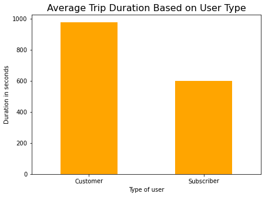

```python
#lets plot a histogram of the average trip duration
# Set an upper limit of 6000
CleanFord_bike.query('duration_sec < 6000').groupby('user_type')['duration_sec'].mean().plot(kind='bar', figsize=(7,5), color = 'orange')
plt.title('Average Trip Duration Based on User Type', fontsize=16, fontweight=None)
plt.xlabel('Type of user')
plt.ylabel('Duration in seconds')
plt.xticks(rotation=1);
```

> We can see although subscribers take a lot more trips than customers, the customers however take the most time on trips

## 4. What is the relation between user type and daily usage

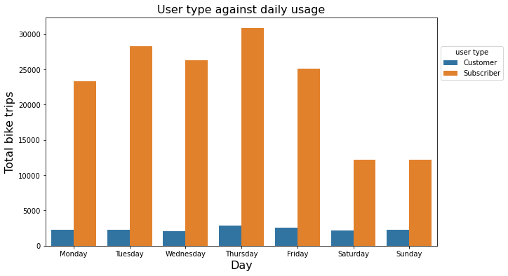

```python
plt.figure(figsize=[10,6])

order = ['Monday','Tuesday','Wednesday','Thursday','Friday', 'Saturday', 'Sunday']

#categorical variables

sb.countplot(data=CleanFord_bike, x='day_of_week',hue ='user_type',order = order);
plt.xticks(rotation = 0);
plt.xlabel('Day',fontsize = 16)
plt.ylabel('Total bike trips',fontsize=16)
plt.title('User type against daily usage',fontsize=16);
# legend to right
plt.legend(title = 'user type',loc = 6, bbox_to_anchor = (1.0, 0.8))
```

- As seen from the visualization, each day of the week the subscribers take the most bike trips than the customer
- There is a sharp contrast between subscriber and customers

### Did you observe any interesting relationships between the other features (not the main feature(s) of interest)?

> I noticed that the distributions makes sense and seems logical

## Multivariate Exploration

> Create plots of three or more variables to investigate your data even further. Make sure that your investigations are justified, and follow from your work in the previous sections.

## 1. What is the gender and trip duration for each user type (gender, user_type and duration_sec) ?

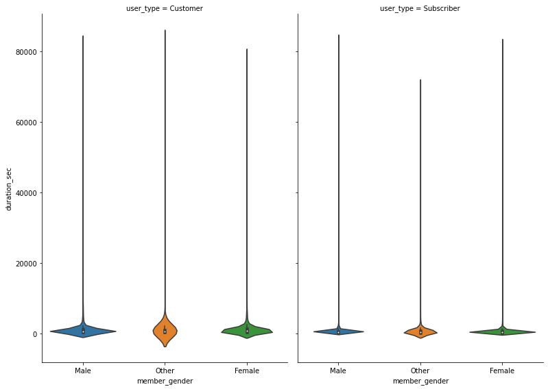

```python
sb.catplot(x = "member_gender", y = "duration_sec",
                col = "user_type",
                data = CleanFord_bike, kind = "violin",
                height=8, aspect=.7);
```

## 2. What is the bike ride comparison between User Groups in each Weekday

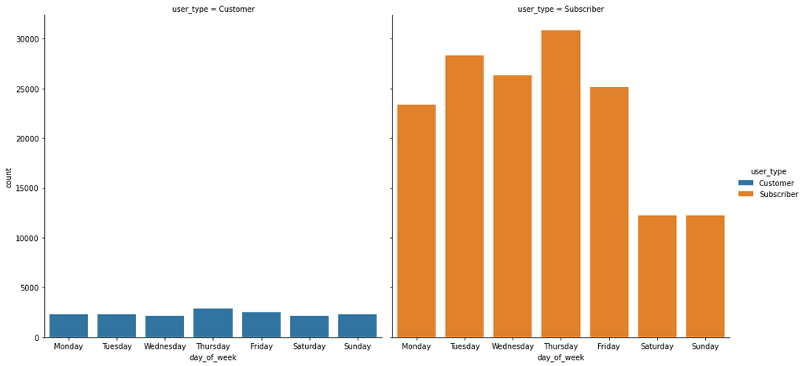

```python
g = sb.FacetGrid(data = CleanFord_bike, col='user_type', height=7 , hue = 'user_type')
order =['Monday','Tuesday','Wednesday','Thursday','Friday','Saturday','Sunday']
g = g.map(sb.countplot, "day_of_week", order = order );
g.add_legend()
plt.show()
```

- As we can see from the visualization, subscribers are the most bike users compared to the customers as expected

## 3. What is the average trip duration associated with user type and different days of the week?

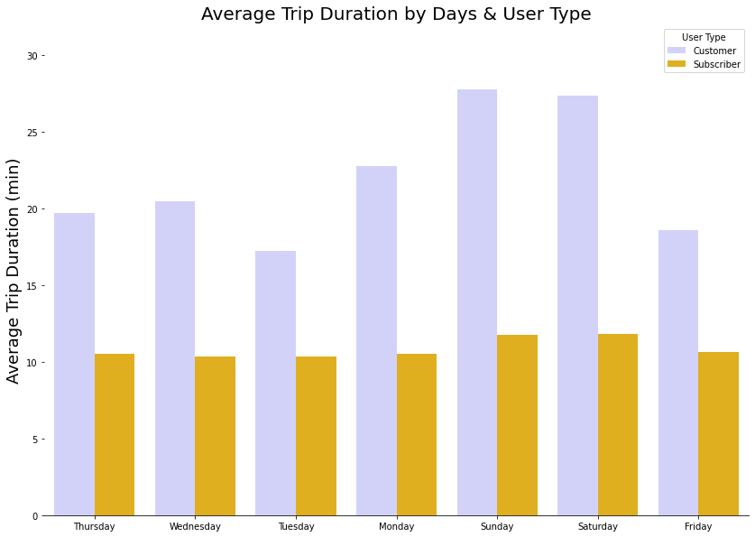

```python
# setting figure size
plt.figure(figsize=[14, 10])

# color and plotting
palette = ['#CCCCFF', '#FFBF00']
ax = sb.barplot(data=CleanFord_bike, x='day_of_week', y='duration_min',
                palette=palette, errwidth=0, hue='user_type')

# Polishing the figure
plt.title('Average Trip Duration by Days & User Type', fontsize=20)
plt.xlabel('')
plt.ylabel('Average Trip Duration (min)', fontsize=18)

# Hide the right, left and top spines
ax.spines['right'].set_visible(False)
ax.spines['top'].set_visible(False)
ax.spines['left'].set_visible(False)

# legends
plt.legend(title='User Type')
plt.show()
```

## 4. What is the distribution of trip duration by day and gender?

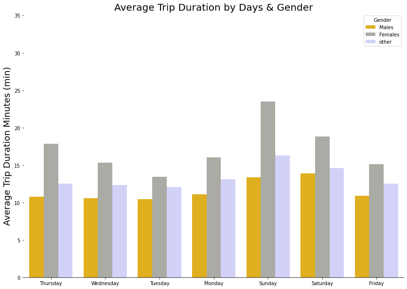

```python
plt.figure(figsize=[14, 10])

# color and plotting
palette = ['#FFBF00', '#acaca4', '#CCCCFF']
ax = sb.barplot(data=CleanFord_bike, x='day_of_week', y='duration_min',
                palette=palette, errwidth=0, hue='member_gender')

# Polishing the figure
plt.title('Average Trip Duration by Days & Gender', fontsize=20)
plt.xlabel('')
plt.ylabel('Average Trip Duration Minutes (min)', fontsize=18)

# Hide the right, left and top spines
ax.spines['right'].set_visible(False)
ax.spines['top'].set_visible(False)
ax.spines['left'].set_visible(False)

# adjusting legends
legends = plt.legend(title='Gender')
labels = ['Males', 'Females', 'other']
i = 0
for label in labels:
    legends.get_texts()[i].set_text(label)
    i += 1
plt.show()
```

### Were there any interesting or surprising interactions between features?

> No

```python
# Export cleaned dataframe to CSV file for slide deck

# Code
CleanFord_bike.to_csv('FordGo_bike.csv', index=None)
df_check = pd.read_csv('FordGo_bike.csv')

# Test
df_check
```

[output not shown]

174875 rows × 22 columns

## References

- Udacity Data Analyst Nanodegree 5.Data Visualization course materials & Example_Project_Diamonds
- https://stackoverflow.com/questions/56942670/matplotlib-seaborn-first-and-last-row-cut-in-half-of-heatmap-plot
- https://svaderia.github.io/articles/downloading-and-unzipping-a-zipfile/
- https://www.freecodecamp.org/news/how-to-combine-multiple-csv-files-with-8-lines-of-code-265183e0854/
- https://stackoverflow.com/questions/36341484/get-day-name-from-weekday-int
- https://stackoverflow.com/questions/37625334/python-pandas-convert-month-int-to-month-name
- https://stackoverflow.com/questions/7066121/how-to-set-a-single-main-title-above-all-the-subplots-with-pyplot
- https://stackoverflow.com/questions/53548973/remove-background-plot-lines-in-pyplot-hist
- https://seaborn.pydata.org/generated/seaborn.catplot.html